# MSBMI 33200: Lecture 4

Anoop Mayampurath

October 28, 2019

### Handling imbalanced data in classification models

Imbalanced data is data where one class (called minority class) is rare relative to the other class (majority class).

Since ML models are fit to maximize accuracy, a model that is good at predicting the majority class will have a very high accuracy in cross-validation. However, when tested on an independent set, the AUC will be very low.

How to handle imbalanced dataset?

1. Change the algorithm.
2. Resample: we sample less from the majority class (i.e., down-sampling the negative class) in the training data

NOTE! Always do this on the training data (after splitting the dataset). You do not do any manipulation of the test dataset.

Sampling can be done:

1. Randomly: randomly sample the majority class without replacement until the dimensions of the majority and the minority class are the same.
2. Focused: choose the majority class points that are farthest away from the minority class points.
3. Cost-sensitive training: Modulate the error function based on class labels.
4. Generate synthetic examples using SMOTE

SMOTE : https://www.jair.org/index.php/jair/article/view/10302

Rather than sampling the minority class with replacement, it creates artificial samples of the minority class.

The algorithm works by joining two minority class points by a line, and then sampling points on that line at random.

All the sythentically generated data points are assigned the minority class.

In SMOTE, you can also down-sample the majority class as well.

You must always do this on the training dataset only.

## R usage

SMOTE is available as part of the DMwR package.

The general formula is

```r
library(DMwR)
trainSampled <- SMOTE (outcome ~ ., data = d.in,
                       perc.over = 200, perc.under = 100, k = 1)
```

There are three parameters to consider in SMOTE

1. perc.over: rate of over-sampling

This is generally > 100. In the above example, for every data point in the minority class, 2 new data points of that class are created.

2. perc.under: rate of under-sampling

This is generally set to 100 to get a 50-50 split of majority and minority. For example, if there are 400 total minority class data points after sampling, then a perc.under of 100 randomly samples 400 data points from the majority class.

3. k: the number of neighbors to connect to

## Python usage

```python
from imblearn.over_sampling import SMOTE
sm = SMOTE(sampling_stratergy = "all", # resample all class (this could be a ratio as a float as well!)
random_state = 456, # set the seed
k_neighbors = 1, # number of neighbors to connect to for the minority oversampling
)
```

### Neural networks

## Recall

Logistic regression models $P(Y=1)$ against $h_{w}(X)$ where $h(z) = \frac {1}{1+e^{-z}}$. In other words,

$$P(Y= 1) = \frac {1}{1+e^{-Xw}}$$

The function $h()$ is called as a sigmod function or logit. It takes the following shape.

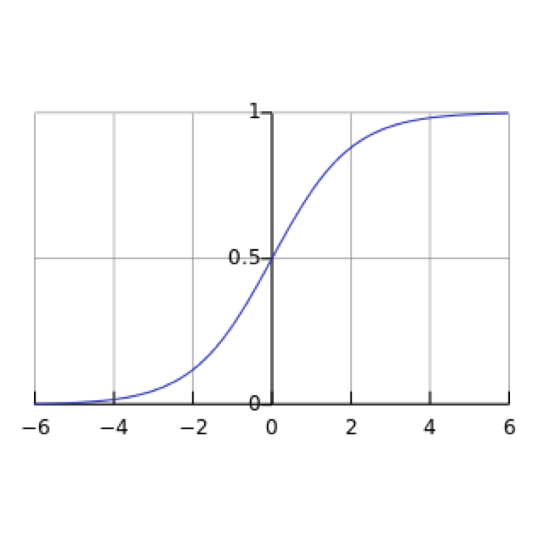

This can be expressed in a “neuron” form (aka node) as:

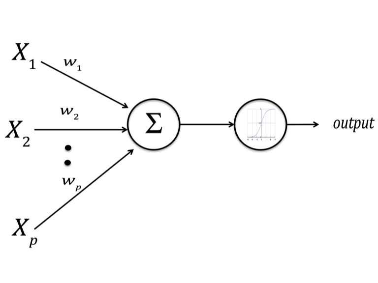

This is the building block of an artificial neural network (or ANN). The sigmoid function is called as the activating function.

ANNs learn trends and patterns in the data by emulating the way a brain works. Simple ANNs utilize a handful of neuron while complex ANN models (such as deep-learning) use a few million neurons. However, it is still several orders of magnitude less complex that what a human brain posseses.

But in general, ANNs has demonstrated great power in classification problems since they can approximate non-linear functions typically present in the real world.

Here is a typical neural network

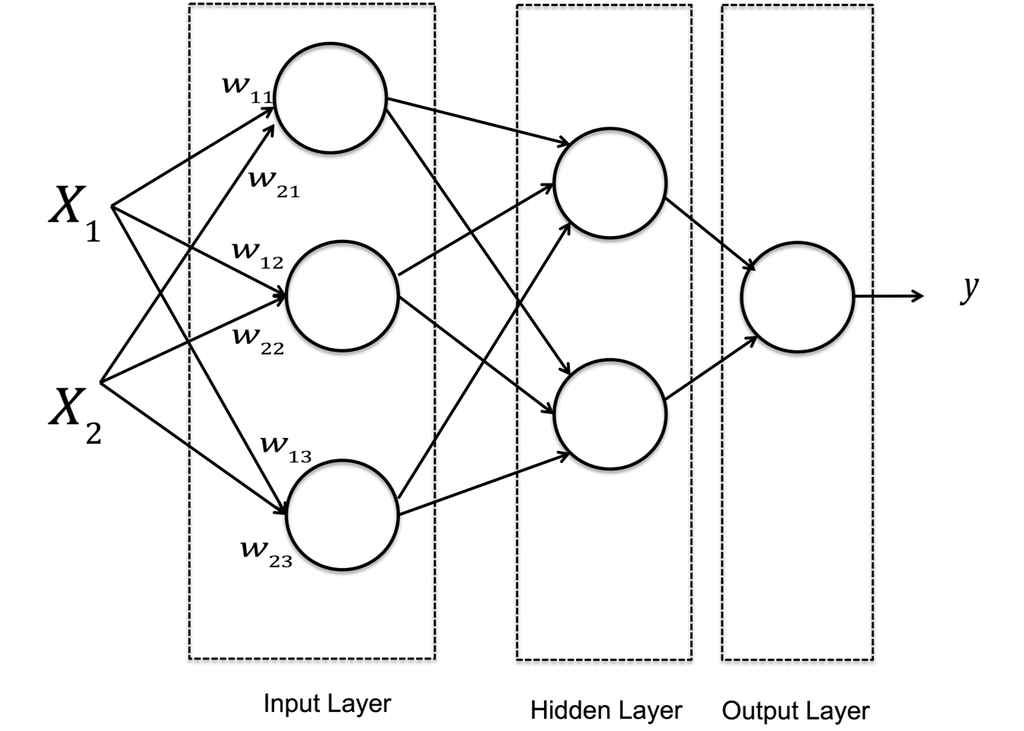

## Structure of ANN

A standard ANN has the following layers of neuron

1. input layer
2. hidden layer
3. output layer

## ANN Learning

Recall: In a logistic regression model, the total loss function for all data points $i= 1 \dots n$ is called as log-loss and is written as:

$$J(w) = - \frac{1}{n} \sum_{i=1}^{n}[y_ilog(\hat{P}) + (1-y_i)log(1-\hat{P})]$$

With regularization, this becomes

$$J(w) = - \frac{1}{n} \sum_{i=1}^{n}[y_ilog(\hat{P}) + (1-y_i)log(1-\hat{P})] + \lambda \sum_{j=1}^{p}w_{j}^{2}$$

where $\hat{P} = \hat{P}(y_i =1)$

This is for set of $w$s

Consider

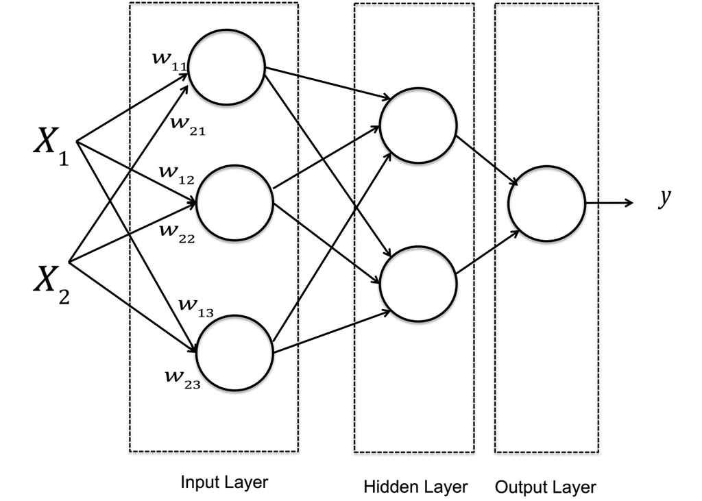

$f^l_{k}(.)$ is the activating function for layer $l$, neuron $k$.

Here we represent all weights as $W = {w^1_{(X1)1}, w^1_{(X2)1}, \dots, w^3_{21}}$

The cost function for a binary classification becomes

$$J(W) = - \frac{1}{n} \sum_{i=1}^{n} [y_ilog(f^{3}_{1}(.)) + (1-y_i)log(1-f^{3}_{1}(.)] + \lambda \sum_{j}\sum_{k}\sum_{l}(w_{jk}^{l})^{2}$$

The first part minimizes the average sum of logistic regressions across the output layer

The second part regularizes all the weights in the neural network

Thus, for different combinations of weights in $W$, the cost function will either go up or go down.

Finding the $W$ that minimizes the above equation is called as “learning”

We are going to understand how a neural network learns by considering two separate algorithms:

1. Forward propagation algorithm
2. Back propagation algorithm

## Forward propagation

1. Initialize all weights in $W$ randomly.
2. Perform a prediction $\hat{y}$ and compare it with true $y$.
3. Calculate $J(W)$ the cost function

Recall that in the logistic regression model, we did a weight update step based on the Gradient Descent algorithm

$$w^{new} = w^{old} - \eta \frac{\partial J(w^{old})}{\partial w^{old}}$$

We use the backpropagation algorithm to do this over $W$

## Back propagation

In backpropagation, this error is propagated through all prior layers.

$$\delta_{1}^2 = w^3_{11}\delta^{3}$$

$$\delta_{2}^2 = w^3_{21}\delta^{3}$$

Then the errors in the hidden layer get propagated to the nodes in the input layer as:

$$\delta_{1}^1 = w^2_{11}\delta_{1}^2 + w^2_{12}\delta_{2}^2$$

$$\delta_{2}^1 = w^2_{21}\delta_{1}^2 + w^2_{22}\delta_{2}^2$$
$$\delta_{3}^1 = w^2_{31}\delta_{1}^2 + w^2_{32}\delta_{2}^2$$

The propagated errors are used to updated the weights to the input layer

$$w^1_{(X1)1} = w^1_{(X1)1} + \eta\delta_{1}^1\frac{df_1^1(x)}{dx}X1$$

$$w^1_{(X1)2} = w^1_{(X1)2} + \eta\delta_{2}^1\frac{df_2^1(x)}{dx}X1$$

$$w^1_{(X1)3} = w^1_{(X1)3} + \eta\delta_{3}^1\frac{df_3^1(x)}{dx}X1$$

$$w^1_{(X2)1} = w^1_{(X2)1} + \eta\delta_{1}^1\frac{df_1^1(x)}{dx}X2$$
$$w^1_{(X2)2} = w^1_{(X2)2} + \eta\delta_{2}^1\frac{df_2^1(x)}{dx}X2$$
$$w^1_{(X2)3} = w^1_{(X2)3} + \eta\delta_{3}^1\frac{df_3^1(x)}{dx}X3$$

The weights on the first node in the hidden layer is updated as follows:

$$w^2_{11} = w^2_{11} + \eta\delta_{1}^2\frac{df_1^2(x)}{dx}{f_1^1(w^1_{(X1)1}X_1 + w^1_{(X2)1}X_2)}$$

or
$$w^2_{11} = w^2_{11} + \eta\delta_{1}^2\frac{df_1^2(x)}{dx}y_1^1$$

Similarly

$$w^2_{21} = w^2_{21} + \eta\delta_{1}^2\frac{df_1^2(x)}{dx}y_2^1$$
$$w^2_{31} = w^2_{31} + \eta\delta_{1}^2\frac{df_1^2(x)}{dx}y_3^1$$

For the second node in the hidden layer, the weight update steps are
$$w^2_{12} = w^2_{12} + \eta\delta_{2}^2\frac{df_2^2(x)}{dx}y_1^1$$
$$w^2_{22} = w^2_{22} + \eta\delta_{2}^2\frac{df_2^2(x)}{dx}y_2^1$$
$$w^2_{32} = w^2_{32} + \eta\delta_{2}^2\frac{df_2^2(x)}{dx}y_3^1$$

For the weights in the ouput layer, the weight update steps are

$$w^3_{11} = w^3_{11} + \eta\delta\frac{df_3^1(x)}{dx}y_1^2$$
$$w^3_{21} = w^3_{21} + \eta\delta\frac{df_3^1(x)}{dx}y_2^2$$

The process is repeated until there are no changes in the weights.

Here is a simplified version of the algorithm:  
1. Initialize all weights randomly.  
2. Perform a prediction $\hat{y}$ and compare it with true $y$.  
3. Calculate miss-classification error $\delta$.  
4. Use the error to update all weights.  
5. Repeat 2-4 until there is no significant change in the weights.

The learning parameter $\eta$ is the equivalent of step size. Typically, this is set as a large value initially and gradually decreased to a small value; this method is called as ‘weight decay’.

For a very good graphical representation of backpropagation, please see http://galaxy.agh.edu.pl/~vlsi/AI/backp_t_en/backprop.html

Parameters to tune in Neural Networks

1. Neural network size: this is the number of nodes in the hidden layer.  
   The input layer typically has 1 + number of features.  
   The output layer has 1-number of class labels.  
   It doesn’t matter if you have 4 hidden layers with 4 nodes or 1 hidden layer with 16 nodes.  
   Thus we only have to tune the number of nodes in the hidden layer.
2. Decay: set this to around 1E-04. However, do consider tuning this from large (0.01) to small (1E-04) values

## Center and scaling

Before using data in the neural network, we have to normalize numeric data so that the weights are changed relative to each other.

One strategy is to normalize the data (i.e. the numeric variables) before splitting into training and test. The downside of this is that it might impact the AUCs. Additionally, this will not help in deploying the model.

Normalization should ideally be done in two stages 1. Normalize training dataset. 2. Use the parameters from the training dataset to guide normalization of the test dataset.

## Doing this in R

```r
preProcValues <- preProcess(d.train, #training dataet
                            method = c("center", "scale") # subtract mean to center, divide by standard deviation
)
```

There are a few other options worth noting in preProcess.

https://www.rdocumentation.org/packages/caret/versions/6.0-84/topics/preProcess

```r
trainTransformed <- predict(preProcValues, d.train)
testTransformed <- predict(preProcValues, d.test)

# These become the new train and test datasets
```

## Doing this in Python

```python
std_scale = preprocessing.StandardScalter().fit(X_train)
X_train_transformed  = std_scale.transform(X_train)
X_test_transformed = std_scale.transform(X_test)
```